# Project Communicate Data Findings:(prosper loan dataset)

**by Mariam Atef Elkenany**

### Introduction

This project is on a data set from Prosper, which is America’s first marketplace lending platform, with over $7 billion in funded loans. This data set contains 113,937 loans with 81 variables on each loan, including loan amount, borrower rate (or interest rate), current loan status, borrower income, borrower employment status, borrower credit history, and the latest payment information.

The main purpose of this project is to summarize the characteristics of variables that can affect the loan status and to get some ideas about the relationships among multiple variables using summary statistics and data visualizations.

**What is the structure of your dataset?**

The dataset contains 113,937 loans with 81 features (including LoanOriginalAmount, BorrowerAPR, StatedMonthlyIncome, Term, ProsperRating (Alpha), EmploymentStatus and many others)

### Preliminary Wrangling

```python
# import required libraries
import numpy as np
import pandas as pd
import matplotlib.pyplot as plt
import seaborn as sns

%matplotlib inline

# suppress warnings from final output
import warnings
warnings.simplefilter("ignore")
```

```python
# load in the dataset
df = pd.read_csv('LoanData.csv')
df.shape
```

```
(113937, 81)
```

```python
df.head()
#print(df.head(6))
```

|  | ListingKey | ListingNumber | ListingCreationDate | CreditGrade | Term | LoanStatus | ClosedDate | BorrowerAPR | BorrowerRate | LenderYield | ... | LP_ServiceFees | LP_CollectionFees | LP_GrossPrincipalLoss | LP_NetPrincipalLoss | LP_NonPrincipalRecoverypayments | PercentFunded | Recommendations | InvestmentFromFriendsCount | InvestmentFromFriendsAmount | Investors |
| --- | --- | --- | --- | --- | --- | --- | --- | --- | --- | --- | --- | --- | --- | --- | --- | --- | --- | --- | --- | --- | --- |
| 0 | 1021339766868145413AB3B | 193129 | 2007-08-26 19:09:29.263000000 | C | 36 | Completed | 2009-08-14 00:00:00 | 0.16516 | 0.1580 | 0.1380 | ... | -133.18 | 0.0 | 0.0 | 0.0 | 0.0 | 1.0 | 0 | 0 | 0.0 | 258 |
| 1 | 10273602499503308B223C1 | 1209647 | 2014-02-27 08:28:07.900000000 | NaN | 36 | Current | NaN | 0.12016 | 0.0920 | 0.0820 | ... | 0.00 | 0.0 | 0.0 | 0.0 | 0.0 | 1.0 | 0 | 0 | 0.0 | 1 |
| 2 | 0EE9337825851032864889A | 81716 | 2007-01-05 15:00:47.090000000 | HR | 36 | Completed | 2009-12-17 00:00:00 | 0.28269 | 0.2750 | 0.2400 | ... | -24.20 | 0.0 | 0.0 | 0.0 | 0.0 | 1.0 | 0 | 0 | 0.0 | 41 |
| 3 | 0EF5356002482715299901A | 658116 | 2012-10-22 11:02:35.010000000 | NaN | 36 | Current | NaN | 0.12528 | 0.0974 | 0.0874 | ... | -108.01 | 0.0 | 0.0 | 0.0 | 0.0 | 1.0 | 0 | 0 | 0.0 | 158 |
| 4 | 0F023589499656230C5E3E2 | 909464 | 2013-09-14 18:38:39.097000000 | NaN | 36 | Current | NaN | 0.24614 | 0.2085 | 0.1985 | ... | -60.27 | 0.0 | 0.0 | 0.0 | 0.0 | 1.0 | 0 | 0 | 0.0 | 20 |

5 rows × 81 columns

```python
df.info()
```

```
<class 'pandas.core.frame.DataFrame'>
RangeIndex: 113937 entries, 0 to 113936
Data columns (total 81 columns):
 #   Column                               Non-Null Count   Dtype
---  ------                               --------------   -----
 0   ListingKey                           113937 non-null  object
 1   ListingNumber                        113937 non-null  int64
 2   ListingCreationDate                  113937 non-null  object
 3   CreditGrade                          28953 non-null   object
 4   Term                                 113937 non-null  int64
 5   LoanStatus                           113937 non-null  object
 6   ClosedDate                           55089 non-null   object
 7   BorrowerAPR                          113912 non-null  float64
 8   BorrowerRate                         113937 non-null  float64
 9   LenderYield                          113937 non-null  float64
```

[output cut: 73 more lines]

```python
df.describe()
```

|  | ListingNumber | Term | BorrowerAPR | BorrowerRate | LenderYield | EstimatedEffectiveYield | EstimatedLoss | EstimatedReturn | ProsperRating (numeric) | ProsperScore | ... | LP_ServiceFees | LP_CollectionFees | LP_GrossPrincipalLoss | LP_NetPrincipalLoss | LP_NonPrincipalRecoverypayments | PercentFunded | Recommendations | InvestmentFromFriendsCount | InvestmentFromFriendsAmount | Investors |
| --- | --- | --- | --- | --- | --- | --- | --- | --- | --- | --- | --- | --- | --- | --- | --- | --- | --- | --- | --- | --- | --- |
| count | 1.139370e+05 | 113937.000000 | 113912.000000 | 113937.000000 | 113937.000000 | 84853.000000 | 84853.000000 | 84853.000000 | 84853.000000 | 84853.000000 | ... | 113937.000000 | 113937.000000 | 113937.000000 | 113937.000000 | 113937.000000 | 113937.000000 | 113937.000000 | 113937.000000 | 113937.000000 | 113937.000000 |
| mean | 6.278857e+05 | 40.830248 | 0.218828 | 0.192764 | 0.182701 | 0.168661 | 0.080306 | 0.096068 | 4.072243 | 5.950067 | ... | -54.725641 | -14.242698 | 700.446342 | 681.420499 | 25.142686 | 0.998584 | 0.048027 | 0.023460 | 16.550751 | 80.475228 |
| std | 3.280762e+05 | 10.436212 | 0.080364 | 0.074818 | 0.074516 | 0.068467 | 0.046764 | 0.030403 | 1.673227 | 2.376501 | ... | 60.675425 | 109.232758 | 2388.513831 | 2357.167068 | 275.657937 | 0.017919 | 0.332353 | 0.232412 | 294.545422 | 103.239020 |
| min | 4.000000e+00 | 12.000000 | 0.006530 | 0.000000 | -0.010000 | -0.182700 | 0.004900 | -0.182700 | 1.000000 | 1.000000 | ... | -664.870000 | -9274.750000 | -94.200000 | -954.550000 | 0.000000 | 0.700000 | 0.000000 | 0.000000 | 0.000000 | 1.000000 |
| 25% | 4.009190e+05 | 36.000000 | 0.156290 | 0.134000 | 0.124200 | 0.115670 | 0.042400 | 0.074080 | 3.000000 | 4.000000 | ... | -73.180000 | 0.000000 | 0.000000 | 0.000000 | 0.000000 | 1.000000 | 0.000000 | 0.000000 | 0.000000 | 2.000000 |
| 50% | 6.005540e+05 | 36.000000 | 0.209760 | 0.184000 | 0.173000 | 0.161500 | 0.072400 | 0.091700 | 4.000000 | 6.000000 | ... | -34.440000 | 0.000000 | 0.000000 | 0.000000 | 0.000000 | 1.000000 | 0.000000 | 0.000000 | 0.000000 | 44.000000 |
| 75% | 8.926340e+05 | 36.000000 | 0.283810 | 0.250000 | 0.240000 | 0.224300 | 0.112000 | 0.116600 | 5.000000 | 8.000000 | ... | -13.920000 | 0.000000 | 0.000000 | 0.000000 | 0.000000 | 1.000000 | 0.000000 | 0.000000 | 0.000000 | 115.000000 |
| max | 1.255725e+06 | 60.000000 | 0.512290 | 0.497500 | 0.492500 | 0.319900 | 0.366000 | 0.283700 | 7.000000 | 11.000000 | ... | 32.060000 | 0.000000 | 25000.000000 | 25000.000000 | 21117.900000 | 1.012500 | 39.000000 | 33.000000 | 25000.000000 | 1189.000000 |

8 rows × 61 columns

```python
# Subset the dataframe by selecting features of interest
col = ['LoanOriginalAmount', 'BorrowerAPR', 'StatedMonthlyIncome', 'Term', 'ProsperRating (Alpha)', 'EmploymentStatus']
loan_subs = df[col]
```

```python
loan_subs.head()
```

|  | LoanOriginalAmount | BorrowerAPR | StatedMonthlyIncome | Term | ProsperRating (Alpha) | EmploymentStatus |
| --- | --- | --- | --- | --- | --- | --- |
| 0 | 9425 | 0.16516 | 3083.333333 | 36 | NaN | Self-employed |
| 1 | 10000 | 0.12016 | 6125.000000 | 36 | A | Employed |
| 2 | 3001 | 0.28269 | 2083.333333 | 36 | NaN | Not available |
| 3 | 10000 | 0.12528 | 2875.000000 | 36 | A | Employed |
| 4 | 15000 | 0.24614 | 9583.333333 | 36 | D | Employed |

```python
# descriptive statistics for numeric variables
loan_subs.describe()
```

|  | LoanOriginalAmount | BorrowerAPR | StatedMonthlyIncome | Term |
| --- | --- | --- | --- | --- |
| count | 113937.00000 | 113912.000000 | 1.139370e+05 | 113937.000000 |
| mean | 8337.01385 | 0.218828 | 5.608026e+03 | 40.830248 |
| std | 6245.80058 | 0.080364 | 7.478497e+03 | 10.436212 |
| min | 1000.00000 | 0.006530 | 0.000000e+00 | 12.000000 |
| 25% | 4000.00000 | 0.156290 | 3.200333e+03 | 36.000000 |
| 50% | 6500.00000 | 0.209760 | 4.666667e+03 | 36.000000 |
| 75% | 12000.00000 | 0.283810 | 6.825000e+03 | 36.000000 |
| max | 35000.00000 | 0.512290 | 1.750003e+06 | 60.000000 |

### cleaning the data

```python
# data wrangling, remove loans with missing borrower APR information
loan_subs = loan_subs[~loan_subs.BorrowerAPR.isna()]
```

What is/are the main feature(s) of interest in your dataset?

I'm most interested in figureing out what features are best for predicting the borrower's Annual Percentage Rate (APR) for the loan.

What features in the dataset do you think will help support your investigation into your feature(s) of interest?

I expect that the total loan amount will have a negative effect on the APR of the loan: the larger the total loan amount, the lower the APR. I also think that the borrowers stated monthly income, loan term, Prosper rating, employment status will also have effects on the APR.

### Univariate Analysis

I'll start by looking at the distribution of the main variable of interest: borrower APR.

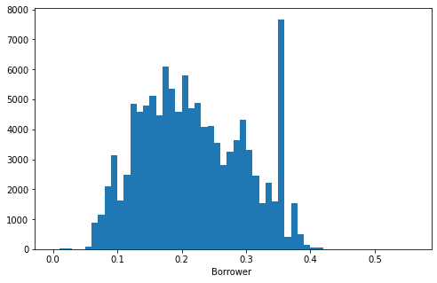

```python
bins = np.arange(0, loan_subs.BorrowerAPR.max()+0.05, 0.01)
plt.figure(figsize=[8, 5])
plt.hist(data = loan_subs, x = 'BorrowerAPR', bins = bins);
plt.xlabel('Borrower ');
```

The distribution of APR looks multimodal. A small peak centered at 0.1, a large peak centered at 0.2. There is also a small peak centered 0.3. Additionally, there is a very shape peak between 0.35 and 0.36. Only very few loans have APR greater than 0.43.

```python
# Check loans with APR greater than 0.43
loan_subs[loan_subs.BorrowerAPR>0.43]
```

|  | LoanOriginalAmount | BorrowerAPR | StatedMonthlyIncome | Term | ProsperRating (Alpha) | EmploymentStatus |
| --- | --- | --- | --- | --- | --- | --- |
| 18326 | 3000 | 0.45857 | 10000.000000 | 36 | NaN | NaN |
| 22195 | 1789 | 0.46201 | 2916.666667 | 36 | NaN | NaN |
| 36018 | 1500 | 0.51229 | 2838.000000 | 36 | NaN | NaN |
| 56761 | 3000 | 0.50633 | 0.000000 | 36 | NaN | NaN |
| 82043 | 3000 | 0.48873 | 1583.333333 | 36 | NaN | NaN |
| 103973 | 2800 | 0.45857 | 3750.000000 | 36 | NaN | NaN |

The 6 borrowers with largest APR have small loan amount and don't have records of Prosper rating and employment status.

Next up, look at the distribution of the first predictor variable of interest: LoanOriginalAmount

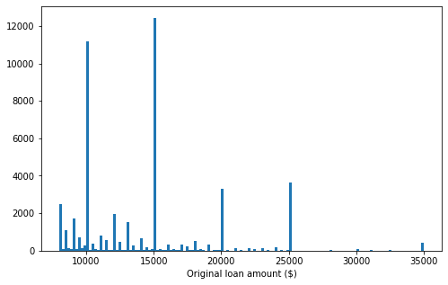

```python
bins = np.arange(8000, loan_subs.LoanOriginalAmount.max()+200, 200)
plt.figure(figsize=[8, 5])
plt.hist(data = loan_subs, x = 'LoanOriginalAmount', bins = bins);
plt.xlabel('Original loan amount ($)');
```

Now, look at the distributions of other variables of interest: stated monthly income

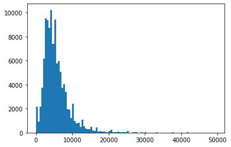

```python
# Distribution of stated monthly income
bins_smi = np.arange(0, 50000, 500)
plt.hist(data = loan_subs, x = 'StatedMonthlyIncome', bins=bins_smi);
```

The distribution of stated monthly income is severely right screwed, with most of stated monthly income less than 30k.

```python
# Check borrowers with stated monthly income greater than 1e5
loan_subs[loan_subs.StatedMonthlyIncome>1e5]
```

|  | LoanOriginalAmount | BorrowerAPR | StatedMonthlyIncome | Term | ProsperRating (Alpha) | EmploymentStatus |
| --- | --- | --- | --- | --- | --- | --- |
| 8066 | 2000 | 0.35643 | 4.166667e+05 | 36 | HR | Employed |
| 8870 | 12500 | 0.12700 | 2.083333e+05 | 36 | NaN | Not available |
| 17411 | 7500 | 0.35643 | 4.833333e+05 | 36 | E | Employed |
| 35218 | 1000 | 0.07389 | 1.083333e+05 | 36 | AA | Full-time |
| 45028 | 4000 | 0.33973 | 1.500000e+05 | 36 | E | Self-employed |
| 53014 | 4000 | 0.25785 | 6.185478e+05 | 12 | D | Self-employed |
| 53167 | 4000 | 0.35797 | 1.750003e+06 | 36 | HR | Self-employed |
| 56867 | 25000 | 0.11144 | 1.850818e+05 | 36 | NaN | Self-employed |
| 57133 | 4000 | 0.35643 | 4.666667e+05 | 36 | E | Employed |
| 59298 | 15000 | 0.24246 | 1.208333e+05 | 36 | C | Self-employed |
| 63925 | 2000 | 0.25948 | 1.404167e+05 | 36 | NaN | Not available |
| 78431 | 5000 | 0.20253 | 1.033341e+05 | 36 | NaN | Full-time |
| 80075 | 25000 | 0.20217 | 1.583333e+05 | 36 | C | Employed |
| 82831 | 4000 | 0.31012 | 2.500000e+05 | 36 | E | Self-employed |
| 83697 | 5000 | 0.08684 | 1.850818e+05 | 36 | NaN | Not available |
| 111265 | 12765 | 0.20593 | 1.087500e+05 | 60 | B | Employed |
| 113270 | 2000 | 0.22712 | 3.944000e+05 | 36 | C | Employed |

```python
# Get percent of borrowers whose stated monthly income greater than 30k
(loan_subs.StatedMonthlyIncome>30000).sum()/float(loan_subs.shape[0])
```

```
0.0028706369829341947
```

Less than 0.3 percent borrowers have stated monthly income greater than 30k, these can be seemed as outlier for the following analysis, so it is better to remove borrower records with income greater than 30k.

```python
# remove loans with stated monthly income greater than 30k, which are outliers
loan_subs = loan_subs[loan_subs.StatedMonthlyIncome<=30000]
```

```python
(loan_subs.StatedMonthlyIncome>30000).sum()
```

```
0
```

Look at distributions of term, Prosper rating and employment status

```python
# Convert ProsperRating and Employment status into ordered categorical types
rate_order = ['HR','E','D','C','B','A','AA']
ordered_var = pd.api.types.CategoricalDtype(ordered = True,categories = rate_order)
loan_subs['ProsperRating (Alpha)'] = loan_subs['ProsperRating (Alpha)'].astype(ordered_var)

emp_order = ['Employed','Self-employed','Full-time','Part-time','Retired','Other','Not employed', 'Not available']
ordered_var = pd.api.types.CategoricalDtype(ordered = True,categories = emp_order)
loan_subs['EmploymentStatus'] = loan_subs['EmploymentStatus'].astype(ordered_var)
```

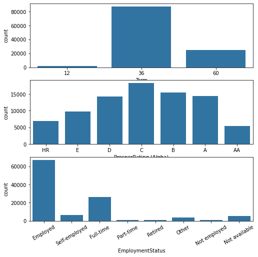

```python
fig, ax = plt.subplots(nrows=3, figsize = [8,8])
default_color = sns.color_palette()[0]
sns.countplot(data = loan_subs, x = 'Term', color = default_color, ax = ax[0])
sns.countplot(data = loan_subs, x = 'ProsperRating (Alpha)', color = default_color, ax = ax[1])
sns.countplot(data = loan_subs, x = 'EmploymentStatus', color = default_color, ax = ax[2]);
plt.xticks(rotation=30);
```

The length of most of the loans are 36 months. The ratings of most of the borrowers are among D to A. Most of borrowers are employed and full-time.

**Discuss the distribution(s) of your variable(s) of interest. Were there any unusual points? Did you need to perform any transformations?**

The distribution of borrowers APR looks multimodal. Most of the values are at the range of 0.05 and 0.4. There are no unusual points and no need to perform any transformations.

**Of the features you investigated, were there any unusual distributions? Did you perform any operations on the data to tidy, adjust, or change the form of the data? If so, why did you do this?**

The distributions of stated monthly income is highly right screwed. Most stated monthly incomes are less than 30k, but some of them are incredibly high, like greater than 100k. Surprisingly, most of borrowers with greater than 100k monthly income only loan less than 5k dollars. So, the very large stated monthly income may be made up. Overall, Less than 0.3 percent borrowers have stated monthly income greater than 30k, these can be seemed as outlier for the following analysis, so it is better to remove borrower records with income greater than 30k.

There is no need to perform any transformations.

### 1.what is the pairwise correlations present between features in the data.?

```python
num_vars = ['LoanOriginalAmount', 'BorrowerAPR', 'StatedMonthlyIncome']
sat_vars = ['Term', 'ProsperRating (Alpha)', 'EmploymentStatus']
```

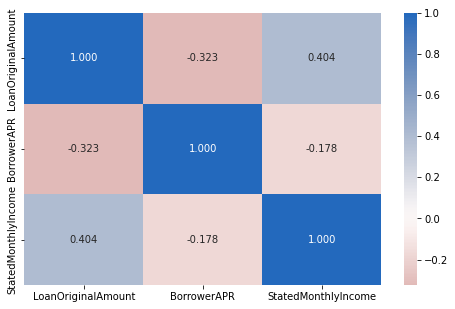

```python
# correlation plot
plt.figure(figsize = [8, 5])
sns.heatmap(loan_subs[num_vars].corr(), annot = True, fmt = '.3f',cmap = 'vlag_r', center = 0);
```

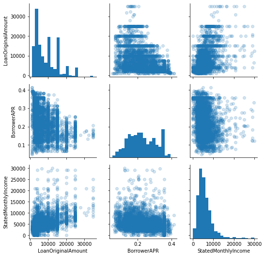

```python
# plot matrix: sample 5000 loans so that plots are clearer and render faster
loan_sub_samp = loan_subs.sample(5000)
g = sns.PairGrid(data = loan_sub_samp.dropna(), vars = num_vars)
g = g.map_diag(plt.hist, bins=20)
g.map_offdiag(plt.scatter, alpha=0.2);
```

The correlation coefficient of borrower APR and loan original amount is -0.323, the scatter plot also shows that these two variables are negatively correlated, which agrees with our hypothesis, that is the more the loan amount, the lower the APR. The loan original amount is positively correlated with the stated monthly income, it makes sense since borrowers with more monthly income could loan more money.

### 2.how borrower APR, stated monthly income and loan original amount correlate with the categorical variables?

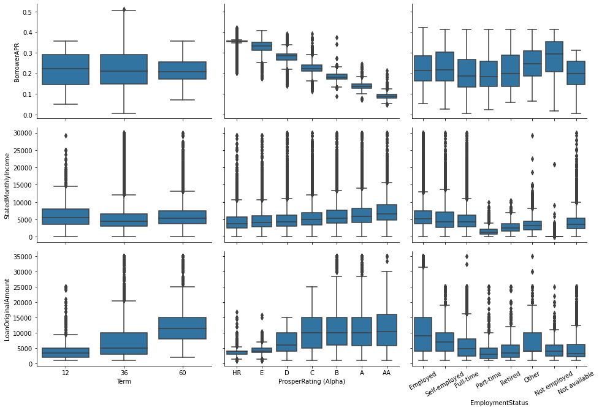

```python
# plot matrix of numeric features against categorical features.
def boxgrid(x, y, **kwargs):
    """ Quick hack for creating box plots with seaborn's PairGrid. """
    default_color = sns.color_palette()[0]
    sns.boxplot(x, y, color = default_color)

plt.figure(figsize = [10, 10])
g = sns.PairGrid(data = loan_subs, y_vars = ['BorrowerAPR', 'StatedMonthlyIncome', 'LoanOriginalAmount'], x_vars = sat_vars, size = 3, aspect = 1.5)
g.map(boxgrid);
plt.xticks(rotation=30);
```

The figure shows that the loan amount is increased with the increase of loan term. The borrower APR decreases with the better rating. Borrowers with the best Prosper ratings have the lowest APR. It means that the Prosper rating has a strong effect on borrower APR. Borrowers with better rating also have larger monthly income and loan amount. Employed, self-employed and full time borrowers have more monthly income and loan amount than part-time, retired and not employed borrowers.

### 3.what the relationships between the three categorical features.?

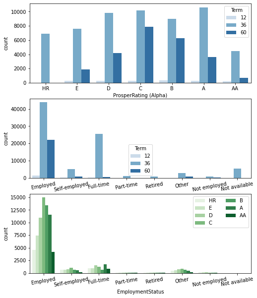

```python
plt.figure(figsize = [8, 10])

# subplot 1: Prosper rating vs term
plt.subplot(3, 1, 1)
sns.countplot(data = loan_subs, x = 'ProsperRating (Alpha)', hue = 'Term', palette = 'Blues')

# subplot 2: employment status vs. term
ax = plt.subplot(3, 1, 2)
sns.countplot(data = loan_subs, x = 'EmploymentStatus', hue = 'Term', palette = 'Blues')
plt.xticks(rotation=10)

# subplot 3: Prosper rating vs. employment status, use different color palette
ax = plt.subplot(3, 1, 3)
sns.countplot(data = loan_subs, x = 'EmploymentStatus', hue = 'ProsperRating (Alpha)', palette = 'Greens')
ax.legend(loc = 1, ncol = 2); # re-arrange legend to remove overlapping
plt.xticks(rotation=10);
```

The employment status variable do not have enough data on part-time, retired and not employed borrowers to show its interaction with term and Prosper rating variables. But we can see that there is a interaction between term and Prosper rating. Proportionally, there are more 60 month loans on B and C ratings. There is only 36 months loans for HR rating borrowers.

With the preliminary look at bivariate relationships out of the way, I want to see

### 4.how borrower APR and loan original amount are related to one another for all of the data.?

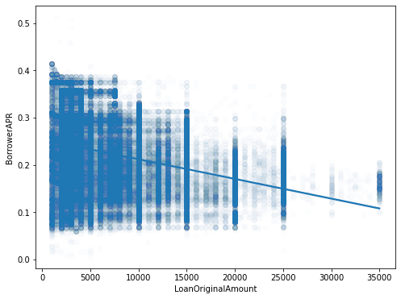

```python
plt.figure(figsize = [8, 6])
sns.regplot(data = loan_subs, x = 'LoanOriginalAmount', y = 'BorrowerAPR', scatter_kws={'alpha':0.01});
```

This plot shows that at different size of the loan amount, the APR has a large range, but the range of APR decrease with the increase of loan amount. Overall, the borrower APR is negatively correlated with loan amount.

**Talk about some of the relationships you observed in this part of the investigation. How did the feature(s) of interest vary with other features in the dataset?**

The borrower APR is negatively associated with the loan original amount, which mean the more the loan amount, the lower the APR. It also shows that at different size of the loan amount, the APR has a large range, but the range of APR decrease with the increase of loan amount. The Prosper rating also has a strong effect on the borrower APR, which decreases with the better rating.

**Did you observe any interesting relationships between the other features (not the main feature(s) of interest)?**

The loan original amount is positively correlated with the stated monthly income, it makes sense since borrowers with more monthly income could loan more money. It also shows that borrowers with better rating also have larger monthly income and loan amount. There is a interaction between prosper rating and term. Proportionally, there are more 60 month loans on B and C ratings. There is only 36 months loans for HR rating borrowers.

## Mutlivariate Analysis

### how the categorical variable (Prosper rating and term) play into the relationship between borrower APR and loan original amount?

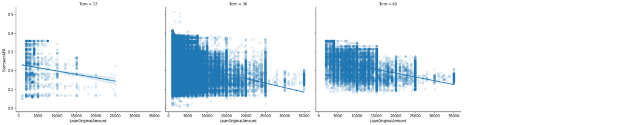

```python
# Term effect on relationship of APR and loan amount
g=sns.FacetGrid(data=loan_subs, aspect=1.2, height=5, col='Term', col_wrap=4)
g.map(sns.regplot, 'LoanOriginalAmount', 'BorrowerAPR', x_jitter=0.04, scatter_kws={'alpha':0.1});
g.add_legend();
```

Term doesn't seem to have effect on relationship of APR and loan amount

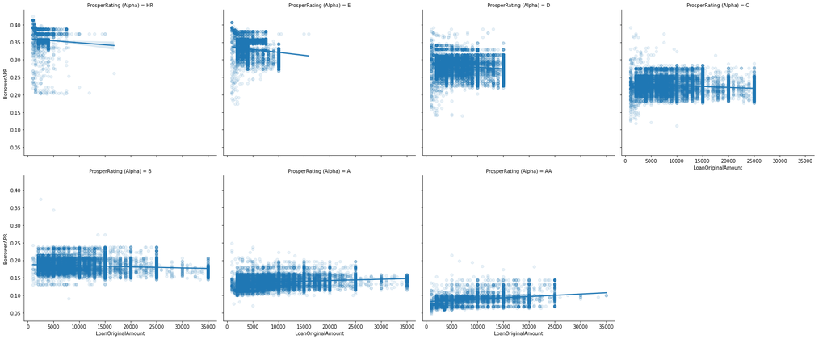

```python
# Prosper rating effect on relationship of APR and loan amount
g=sns.FacetGrid(data=loan_subs, aspect=1.2, height=5, col='ProsperRating (Alpha)', col_wrap=4)
g.map(sns.regplot, 'LoanOriginalAmount', 'BorrowerAPR', x_jitter=0.04, scatter_kws={'alpha':0.1});
g.add_legend();
```

The loan amount increases with better rating. The borrower APR decreases with better rating. Interestingly, the relationship between borrower APR and loan amount turns from negative to slightly positive when the Prosper ratings are increased from HR to A or better. This may because people with A or AA ratings tend to borrow more money, increasting APR could prevent them borrow even more and maximize the profit. But people with lower ratings tend to borrow less money, decreasing APR could encourage them to borrow more.

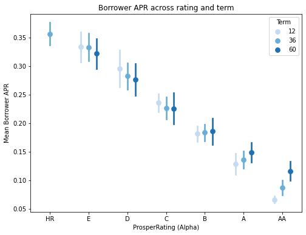

```python
fig = plt.figure(figsize = [8,6])
ax = sns.pointplot(data = loan_subs, x = 'ProsperRating (Alpha)', y = 'BorrowerAPR', hue = 'Term',palette = 'Blues', linestyles = '', dodge = 0.4, ci='sd')
plt.title('Borrower APR across rating and term')
plt.ylabel('Mean Borrower APR')
ax.set_yticklabels([],minor = True);
```

the borrower APR decrease with the increase of borrow term for people with HR-C raings. But for people with B-AA ratings, the APR increase with the increase of borrow term.

Then, look at the rating and term effects on stated monthly income and loan original amount variables

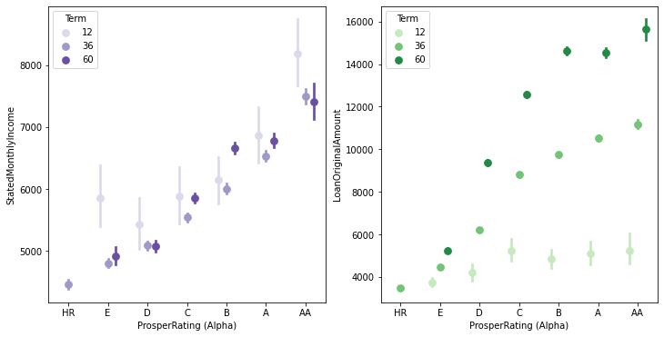

```python
fig, ax = plt.subplots(ncols=2, figsize=[12,6])
sns.pointplot(data = loan_subs, x = 'ProsperRating (Alpha)', y = 'StatedMonthlyIncome', hue = 'Term',
           palette = 'Purples', linestyles = '', dodge = 0.4, ax=ax[0])
sns.pointplot(data = loan_subs, x = 'ProsperRating (Alpha)', y = 'LoanOriginalAmount', hue = 'Term',
           palette = 'Greens', linestyles = '', dodge = 0.4, ax=ax[1]);
```

For stated monthly income, it doesn't seem like there is a interaction effect between term and rating, the pattern of term is similar among different ratings. But for loan amount, there is a interaction between term and rating. We can see that with better Prosper rating, the loan amount of all three terms increases, the increase amplitude of loan amount between terms also becomes larger.

I extended my investigation of borrower APR against loan amount by looking at the impact of the Prosper rating. The multivariate exploration showed that the relationship between borrower APR and loan amount turns from negative to slightly positive when the Prosper ratings increased from HR to AA. I then explored the rating and term effects on loan amount, it shows that with better Prosper rating, the loan amount of all three terms increases, the increase amplitude of loan amount between terms also becomes larger.

**Were there any interesting or surprising interactions between features?**

A surprising interaction is that the borrower APR and loan amount is negatively correlated when the Prosper ratings are from HR to B, but the correlation is turned to be positive when the ratings are A and AA. Another interesting thing is that the borrower APR decrease with the increase of borrow term for people with HR-C raings. But for people with B-AA ratings, the APR increase with the borrow term.

!jupyter nbconvert Airlines_Delay_and_Cancellation_Analysis.ipynb --to slides --no-input